# Statistical Inference Project 1

Helen

23 October 2018

## Overview

This project compares the theory of the exponential distribution with simulated examples. This was done by taking the mean of 40 samples from an exponential distribution. This was repeated 1000 times, resulting in a sample of 1000 means.

## Simulations

For the purposes of this project lambda (l) was set to 0.2. From the properties of exponential distributions, this means that the mean and standard deviation of the exponential distribution are both equal to 5 (i.e. 1 / 0.2).

The code below shows 40 draws from an exponential distribution. The mean of the 40 draws is then calculated and stored in m.

```r
l <- 0.2
draws <- rexp(40, l)
draws
```

```
##  [1] 13.8097797  2.8078536  0.5893606  4.6642467  2.4903574  6.3679690
##  [7]  3.4567039 11.0402336  1.6018714 11.0188691  4.3793547  4.7069541
## [13]  0.3376315  8.2419988  4.4730556  2.4578402  1.8630871 14.4473089
## [19] 10.9650214  1.9277873 11.0318058  6.8799399  4.1062947  1.9920228
## [25]  4.6970794  9.0870326  0.3391383  0.2217438  2.5300865  2.0843596
## [31]  2.4163620  8.9097400  0.1667233  0.2877643  1.9561083  0.2387587
## [37]  7.7960619  0.3390843  4.9878173 16.5326405
```

```r
m <- mean(draws)
m
```

```
## [1] 4.956196
```

This was repeated 1000 times, resulting in a vector of 1000 means. Each mean was calculated by taking the average of 40 draws from the exponential distribution.

```r
means <- NULL
for (i in 1:1000) means <- c(means, mean(rexp(40, l)))
means <- data.frame(means, "means")
colnames(means) <- c("value", "type")
```

## Sample Mean versus Theoretical Mean

The distribution of the 1000 means is plotted below in a histogram. The mean of the distribution is shown by the vertical magenta line.

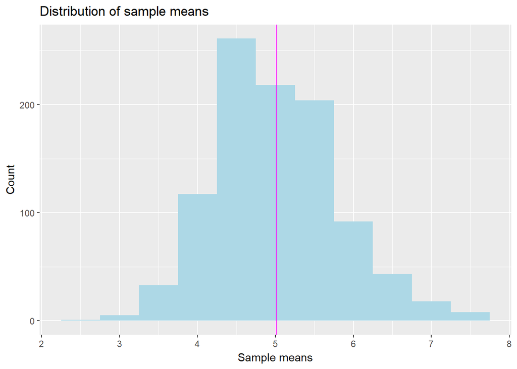

```r
g <- ggplot(means, aes(means))
g + geom_histogram(binwidth = 0.5, fill = "light blue") + geom_vline(xintercept = mean(means[, 1]), color = "magenta") + ggtitle("Distribution of sample means") + ylab("Count") + xlab("Sample means")
```

The mean of this distribution (i.e the “sample mean”) is shown by the vertical magenta line. It can be seen that the sample mean is very slightly larger than the theoretical mean of 5. The differences are compared below.

```r
sample_mean <- mean(means[,1])
theoretical_mean <- 1/l
sample_mean - theoretical_mean
```

```
## [1] 0.008413275
```

It can be seen that the means are close, but not the same. This is because the theoretical mean is the mean of the entire population of exponential draws. In other words, if we did the above experiment infinite times we would achieve the same mean. However, because we did not simulate infinite samples the result is slightly different due to randomness.

## Sample Variance versus Theoretical Variance

The theoretical standard deviation of the exponential distribution is the same as its mean. In this case, this is 5. The variance is the square of the standard deviation, i.e. 25.

The variance of the distribution of means is related to the variance of the exponential distribution in the following way: *The variance of the exponential distribution / the sample size = the variance of the distribution of the means.*

The R code below shows that the simulations imply a exponential distribution standard deviation which is approximately equal to the theoretical standard deviation.

```r
var_sample_means <- var(means[, 1])
var_sample_means
```

```
## [1] 0.6317945
```

```r
implied_var <- var_sample_means * 40
implied_sd <- sqrt(implied_var)
implied_sd
```

```
## [1] 5.027104
```

```r
theoretical_sd <- 1/l

implied_sd - theoretical_sd
```

```
## [1] 0.02710435
```

## Approximately Normal

It was seen above that the distributions of means from 40 exponential draws was approximately normal (or gaussian) shaped. As the size and number of samples increases, the normality of distribution of the means increases.

This is not the case if instead the exponential distribution is sampled without averaging. The graph below compares these two scenarios. The first panel shows the distribution of 1000 means of 40 exponential draws, and the second panel shows the distribution of 1000 exponential draws.

```r
exp_draws <- NULL
for (i in 1:1000) exp_draws <- c(exp_draws,rexp(1, l))
exp_draws <- data.frame(exp_draws, "draws")
colnames(exp_draws) <- c("value", "type")
data_comp <- rbind(means, exp_draws)
head(data_comp)
```

```
##      value  type
## 1 4.527055 means
## 2 5.098838 means
## 3 3.983789 means
## 4 4.737064 means
## 5 5.119272 means
## 6 3.660503 means
```

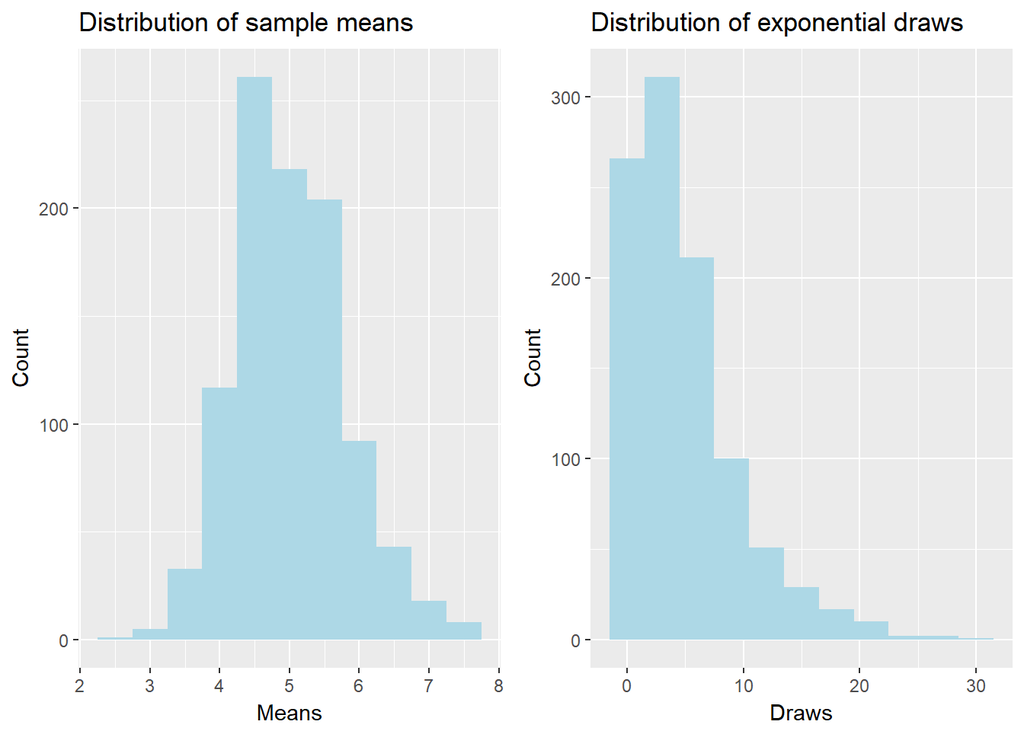

```r
g1 <- ggplot(means, aes(x = value)) + geom_histogram(binwidth = 0.5, fill = "light blue") + ggtitle("Distribution of sample means") + ylab("Count") + xlab("Means")
g2 <- ggplot(exp_draws, aes(x = value)) + geom_histogram(binwidth = 3, fill = "light blue") + ggtitle("Distribution of exponential draws") + ylab("Count") + xlab("Draws")
grid.arrange(g1, g2, ncol = 2)
```

It can be seen that the first graph looks approximately bell-curve shaped whereas the second looks exponential.

We can confirm the approximate gaussian nature of the distribution of the sample means by looking at the properties of the distribution and comparing them with a theoretical normal distribution centred around 5.

A normal distribution with mean 5 would have equal density (50%) either side of the mean.

```r
pnorm(0, lower.tail = TRUE)
```

```
## [1] 0.5
```

```r
pnorm(0, lower.tail = FALSE)
```

```
## [1] 0.5
```

The code below calculates how many of the 1000 data points fall either side of the mean in the distribution of the sample means.

```r
m <- mean(means[, 1])
less_than_m <- sum(means[, 1] < m)
more_than_m <- sum(means[, 1] > m)
less_than_m / 1000
```

```
## [1] 0.527
```

```r
more_than_m / 1000
```

```
## [1] 0.473
```

This shows that 52.7% of the 1000 means were less than 5 and 47.3% were greater than 5. This is not exactly 50/50 but would approach this result as our sample size and number of simulations increased.

The distribution of exponential draws has a very different density each side of the mean as shown below.

```r
n <- mean(exp_draws[, 1])
less_than_n <- sum(exp_draws[, 1] < n)
more_than_n <- sum(exp_draws[, 1] > n)
less_than_n / 1000
```

```
## [1] 0.605
```

```r
more_than_n / 1000
```

```
## [1] 0.395
```

We can also check to see whether the expected density of points falls within one standard deviation of the mean. For a normal distribution the density within one standard deviation is:

```r
pnorm(1) - pnorm(-1)
```

```
## [1] 0.6826895
```

For the distribution of the sample means the density within one standard deviation is:

```r
s <- sd(means[, 1])
first_sd <- sum(means[, 1] < (m+s)) - sum(means[, 1] < (m-s))
first_sd / 1000
```

```
## [1] 0.706
```

This compares to the density seen for the distribution of the 1000 exponential draws:

```r
t <- sd(exp_draws[, 1])
first_td <- sum(exp_draws[, 1] < (n+t)) - sum(exp_draws[, 1] < (n-t))
first_td / 1000
```

```
## [1] 0.799
```

These properties of the distribution of the sample means show that the distribution is approximately gaussian.